# R Laboratory 6

```r
library(ggplot2)
library(latex2exp)
library(coda)
library(rjags)
```

## Exercise 1

• a well established and diffused method for detecting a disease in blood fails to detect the presence of disease in 15% of the patients that actually have the disease.

• A young UniPD startUp has developed an innovative method of screening. During the qualification phase, a random sample of n = 75 patients known to have the disease is screened using the new method.

1. what is the probability distribution of y, the number of times the new method fails to detect the disease ?

If $p$ is the probability of a failure with the new method
$$P(y|p,n) = {n \choose y} \cdot p^y \cdot (1-p)^{n-y}$$

2. on the n = 75 patients sample, the new method fails to detect the disease in y = 6 cases. What is the frequentist estimator of the failure probability of the new method ?

An unbiased frequentist estimator of the failure is:
$$p_{fail} = \frac{y}{n} = \frac{6}{75} = 0.08 = 8 \%$$

3. setup a bayesian computation of the posterior probability, assuming a beta distribution with mean value 0.15 and standard deviation 0.14. Plot the posterior distribution for the probability of y, and mark on the plot the mean value and variance

Considering a Beta distribution:
$$\mu = \frac{\alpha}{\alpha + \beta} \quad , \quad \sigma^2= \frac{\alpha\beta}{(\alpha + \beta)^2 \cdot (\alpha+\beta+1)}$$
These equations lead to:

$$\alpha = - \frac{\mu(\sigma^2 + \mu^2 - \mu)}{\sigma^2} \quad , \quad \beta = \frac{(\sigma^2 + \mu^2 -\mu)(\mu -1)}{\sigma^2}$$

4. Perform a test of hypothesis assuming that if the probability of failing to the detect the disease in ill patients is greater or equal than 15%, the new test is no better that the traditional method.

Test the sample at a 5% level of significance in the Bayesian way.

5. Perform the same hypothesis test in the classical frequentist way.

```r
n_sample <- 75

#b)
y=6
p_new_fail <- y/n_sample
cat("Probability to fail with the new method",p_new_fail)
```

```
Probability to fail with the new method 0.08
```

```r
#c)

x_data <- 500
x_ax <- seq(0,1, length.out = x_data)

mu <- 0.15
sigma <- 0.14

alpha_prior <- (-mu*(sigma^2 + mu^2 - mu))/(sigma^2)
beta_prior <- ((sigma^2 + mu^2 - mu)*(mu -1))/(sigma^2)

cat("Prior Parameters:
    \t alpha = ", round(alpha_prior, 4),"
    \t beta =", round(beta_prior,4),"\n")
```

```
Prior Parameters:
         alpha =  0.8258
         beta = 4.6793
```

```r
#beta prior is a conjugate of a binomial likelihood -> beta posterior

alpha_posterior <- alpha_prior + y
beta_posterior <- beta_prior + n_sample - y

mu_post <- (alpha_posterior)/(alpha_posterior + beta_posterior)
var_post <- (alpha_posterior*beta_posterior)/( ((alpha_posterior + beta_posterior)^2)*(alpha_posterior + beta_posterior + 1))

cat("Posterior Parameters:
    \t alpha = ", round(alpha_posterior, 4),"
    \t beta =", round(beta_posterior ,4),"
    \t mu =", round(mu_post,4),"
    \t var =", round(var_post,6))
```

```
Posterior Parameters:
         alpha =  6.8258
         beta = 73.6793
         mu = 0.0848
         var = 0.000952
```

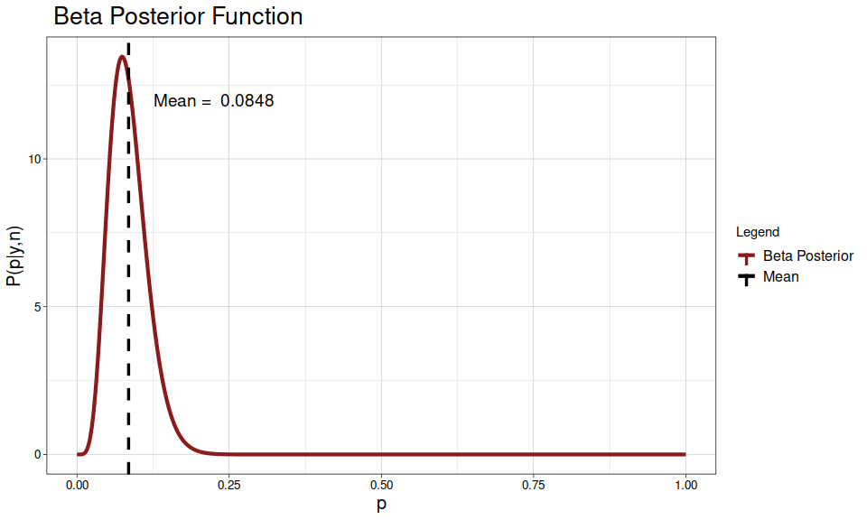

```r
posterior <- function(x){ dbeta(x,alpha_posterior,beta_posterior) }


plot <- ggplot() + theme_linedraw() +
  geom_line(aes(x=x_ax, y=posterior(x_ax), color='Beta Posterior'), lwd=1.5) +
  geom_vline( aes(xintercept = mu_post, color = 'Mean') , linetype='dashed', lwd=1.2)+
  annotate('text', x=mu_post+0.14, y=12, label=paste('Mean = ', round(mu_post, 4)), size=5)+
            ggtitle(" Beta Posterior Function")+
            labs(x="p", y='P(p|y,n)', color='Legend') +
                        theme(legend.text=element_text(size=12))+
                          theme(plot.title = element_text(size=20),
                          axis.text.x = element_text(size=10),
                          axis.text.y = element_text(size=10),
                          axis.title.x = element_text(size=15),
                          axis.title.y = element_text(size=15)) +
     scale_color_manual(values = c( 'Beta Posterior' = 'firebrick4', 'Mean'='black'))

plot
```

Null Hypothesis that the probability of failing in the detection of the disease is greater or equal than the one with the old method, i.e. 15%

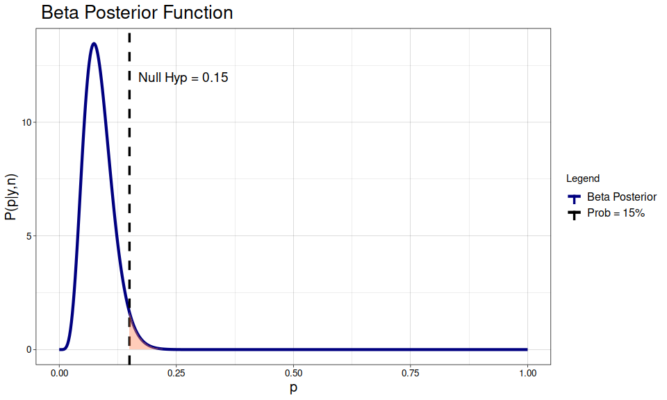

```r
plot <- ggplot() + theme_linedraw() +
  geom_line(aes(x=x_ax, y=posterior(x_ax), color='Beta Posterior'), lwd=1.5) +
  geom_vline( aes(xintercept = 0.15, color = 'Prob = 15%') , linetype='dashed', lwd=1.2)+
  annotate('text', x=0.15+0.115, y=12, label=paste('Null Hyp = 0.15'), size=5)+
geom_ribbon(aes(x=seq(0.15,1,0.01),ymin=0,ymax=dbeta(seq(0.15,1,0.01),alpha_posterior,beta_posterior)),alpha=0.4,fill ='coral')   + ggtitle(" Beta Posterior Function")+
            labs(x="p", y='P(p|y,n)', color='Legend') +
                        theme(legend.text=element_text(size=12))+
                          theme(plot.title = element_text(size=20),
                          axis.text.x = element_text(size=10),
                          axis.text.y = element_text(size=10),
                          axis.title.x = element_text(size=15),
                          axis.title.y = element_text(size=15)) +
     scale_color_manual(values = c( 'Beta Posterior' = 'navy', 'Prob = 15%'='black'))

plot
```

```r
prob <- integrate(posterior, lower=0.15,upper = 1)

cat("The zone of interest corresponds to a Probability of", round(prob$value ,4))
```

```
The zone of interest corresponds to a Probability of 0.0313
```

```r
if(prob$value < 0.05){
  cat("The value of the integral is smaller than the alpha level of significance (5%), so we reject the null hypothesis")
} else{
  cat("The value of the integral is greater than the alpha level of significance (5%), so we can not reject the null hypothesis")
}
```

```
The value of the integral is smaller than the alpha level of significance (5%), so we reject the null hypothesis
```

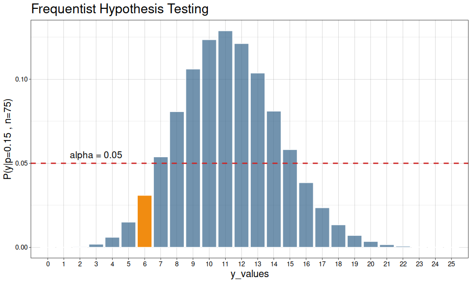

```r
p_null <- 0.15
y_vec <- 0:25

plot <- ggplot() + theme_linedraw() +
  geom_col(aes(x=y_vec, y=dbinom(y_vec, size = n_sample, prob=p_null)), color='white', fill='steelblue4', alpha=0.7) +
  geom_col(aes(x=6, y=dbinom(6, size = n_sample, prob=p_null)), color='white', fill='darkorange', alpha=0.9) +
  geom_hline(yintercept=0.05, color='firebrick3', linetype='dashed', size=0.9)+
  annotate('text', x=3, y=0.055, label='alpha = 0.05', size=5)+
     ggtitle("Frequentist Hypothesis Testing") +
            labs(x="y_values", y='P(y|p=0.15 , n=75)') +
                          theme(plot.title = element_text(size=20),
                          axis.text.x = element_text(size=10),
                          axis.text.y = element_text(size=10),
                          axis.title.x = element_text(size=15),
                          axis.title.y = element_text(size=15))+
                      scale_x_discrete(limits=(0:25), labels=0:25)

plot
```

For the Fisher’s Method we need to calculate the p-value:
$$p\text{-}value = \sum_{y=0}^{6}{P(y|p_0,n)} = \sum_{y=0}^{6}{Binom(y|p_0,n)}$$

```r
#Fisher's Method

p_val <- pbinom(6, size=n_sample, prob=p_null)

cat("The calculated p-value is -->", round(p_val,4))
```

```
The calculated p-value is --> 0.0544
```

```r
if(p_val < 0.05){
  cat("The p-value is smaller than the alpha level of significance (5%), so we reject the null hypothesis")
} else{
  cat("The p-value is greater than the alpha level of significance (5%), so we can not reject the null hypothesis")
}
```

```
The p-value is greater than the alpha level of significance (5%), so we can not reject the null hypothesis
```

## Exercise 2

• Ladislaus Josephovich Bortkiewicz was a Russian economist and statistician. He noted that the Poisson distribution can be very useful in applied statistics when describing low-frequency events in a large population. In a famous example he showed that the number of deaths by horse kick among the Prussian army follows the Poisson distribution.

• Considering the following to sets of observations taken over a fixed large time interval in two different corps:

| y death soldiers | 0 | 1 | 2 | 3 | 4 | $\geq$ 5 |
| --- | --- | --- | --- | --- | --- | --- |
| $n_1$ observations | 109 | 65 | 22 | 3 | 1 | 0 |
| $n_2$ observations | 144 | 91 | 32 | 11 | 2 | 0 |

1. assuming a uniform prior, compute and plot the posterior distribution for λ, the death rate over the measurement time. Determine the posterior mean, median and variance, and compute the 95% credibility interval.

Assuming a uniform prior, with a Poisson distribution, the posterior becomes a Gamma distribution $Gamma(\alpha,\beta)$ with:
$$\alpha = \sum_{i}{y_i + 1} \quad , \quad \beta = n$$
where $n$ is the number of observations.

$$n = \sum_{i=0}^4{ \big[(n_1)_i + (n_2)_i\big]} \quad , \quad \sum_{i}{y_i} = \sum_{i=0}^4{ i \cdot \big[(n_1)_i + (n_2)_i \big]}$$
(b) assuming now a Jeffreys’ prior,

$$g(\lambda) \propto \frac{1}{\sqrt{\lambda}} , \quad \text{with } \lambda > 0$$

compute and plot the posterior distribution for λ, the death rate over the measurement time.

Determine the posterior mean, median and variance, and compute the 95% credibility interval.

```r
deaths <- c(0,1,2,3,4,5)
n1 <- c(109,65,22,3,1,0)
n2 <- c(144,91,32,11,2,0)


alpha_post <- sum(deaths*(n1 + n2)) + 1
beta_post <- sum(n1 + n2)

x_ax <- seq(0.25, 1, 0.001)

posterior_gamma <- dgamma(x_ax, shape = alpha_post, rate = beta_post)
mean_post_u <- alpha_post/beta_post
var_post_u <- alpha_post/(beta_post^2)
median_post_u <- qgamma(0.5, shape = alpha_post, rate = beta_post)

l_bound_CI_u <- qgamma(0.025, shape = alpha_post, rate = beta_post)
u_bound_CI_u <- qgamma(0.975, shape = alpha_post, rate = beta_post)

cat("Posterior Parameters - with Uniform:
    \t alpha = ", round(alpha_post, 4),"
    \t beta =", round(beta_post ,4),"
    \t mean =", round(mean_post_u,4),"
    \t var =", round(var_post_u,6),"
    \t median =", round(median_post_u,4))
```

```
Posterior Parameters - with Uniform:
         alpha =  319
         beta = 480
         mean = 0.6646
         var = 0.001385
         median = 0.6639
```

```r
cat("95 % Credibility Interval :
    \t", l_bound_CI_u, "-", u_bound_CI_u)
```

```
95 % Credibility Interval :
         0.5936468 - 0.7394654
```

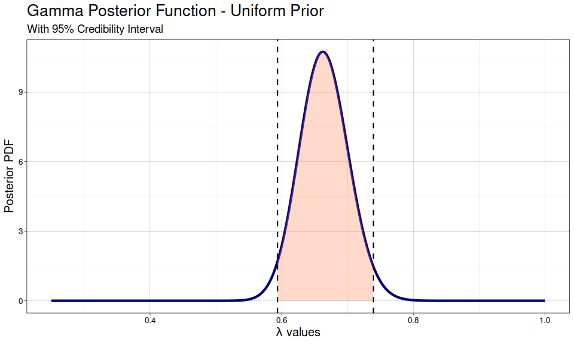

```r
x_area <- seq(l_bound_CI_u, u_bound_CI_u, 0.001)
y_ribbon <- dgamma(x_area, shape = alpha_post, rate = beta_post)


plot <- ggplot() + theme_linedraw() +
       geom_line(aes(x=x_ax, y=posterior_gamma), color='navy', lwd=1.5) +
        geom_vline(xintercept = l_bound_CI_u , linetype='dashed', lwd=0.8) +
        geom_vline(xintercept = u_bound_CI_u , linetype='dashed', lwd=0.8) +
        geom_ribbon(aes(x=x_area, ymin=0 , ymax=y_ribbon), alpha =0.3, fill ='coral') +
     ggtitle("Gamma Posterior Function - Uniform Prior")+
        labs( x=TeX('$\\lambda$ values'), y='Posterior PDF',
           subtitle="With 95% Credibility Interval" )+
                  theme(plot.title = element_text(size=20),
                  plot.subtitle = element_text(size=14),
                  axis.text.x = element_text(size=10),
                  axis.text.y = element_text(size=10),
                  axis.title.x = element_text(size=15),
                  axis.title.y = element_text(size=15))

plot
```

```r
NA
NA
NA
```

Assuming this time a Jeffrey’s prior, with a Poisson distribution, the posterior becomes a Gamma distribution $Gamma(\alpha,\beta)$ with:
$$\alpha = \sum_{i}{y_i + \frac{1}{2}} \quad , \quad \beta = n$$
where $n$ is the number of observations.

```r
#Now with the Jeffrey's Prior

alpha_post <- sum(deaths*(n1 + n2)) + 1/2
beta_post <- sum(n1 + n2)

x_ax <- seq(0.25, 1, 0.001)

posterior_gamma <- dgamma(x_ax, shape = alpha_post, rate = beta_post)
mean_post_j <- alpha_post/beta_post
var_post_j <- alpha_post/(beta_post^2)
median_post_j <- qgamma(0.5, shape = alpha_post, rate = beta_post)

l_bound_CI_j <- qgamma(0.025, shape = alpha_post, rate = beta_post)
u_bound_CI_j <- qgamma(0.975, shape = alpha_post, rate = beta_post)

cat("Posterior Parameters - with Jeffrey's:
    \t alpha = ", round(alpha_post, 4),"
    \t beta =", round(beta_post ,4),"
    \t mean =", round(mean_post_j,4),"
    \t var =", round(var_post_j,6),"
    \t median =", round(median_post_j,4))
```

```
Posterior Parameters - with Jeffrey's:
         alpha =  318.5
         beta = 480
         mean = 0.6635
         var = 0.001382
         median = 0.6628
```

```r
cat("95 % Credibility Interval :
    \t", l_bound_CI_j, "-", u_bound_CI_j)
```

```
95 % Credibility Interval :
         0.5926624 - 0.7383665
```

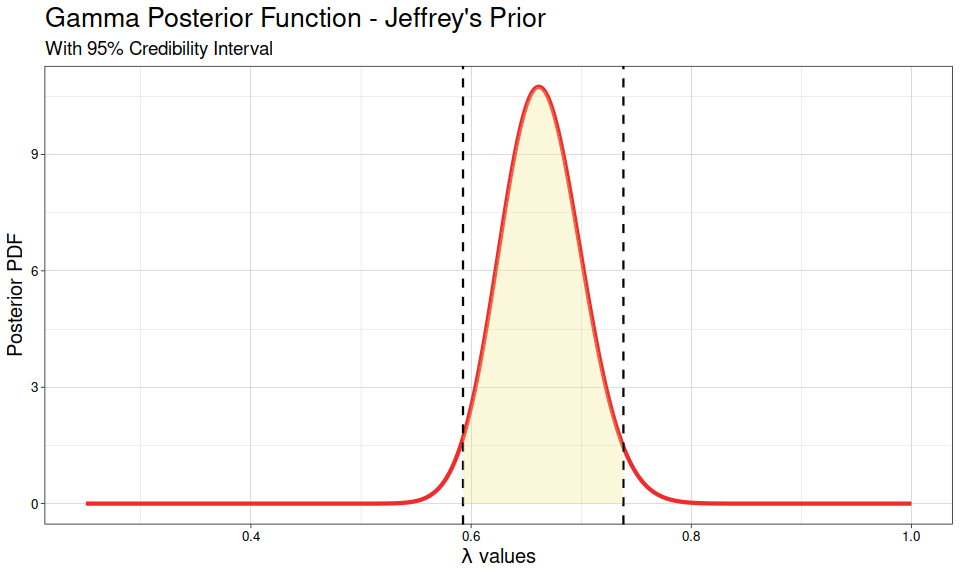

```r
x_area <- seq(l_bound_CI_j, u_bound_CI_j, 0.001)
y_ribbon <- dgamma(x_area, shape = alpha_post, rate = beta_post)


plot <- ggplot() + theme_linedraw() +
       geom_line(aes(x=x_ax, y=posterior_gamma), color='firebrick2', lwd=1.5) +
        geom_vline(xintercept = l_bound_CI_j , linetype='dashed', lwd=0.8) +
        geom_vline(xintercept = u_bound_CI_j , linetype='dashed', lwd=0.8) +
        geom_ribbon(aes(x=x_area, ymin=0 , ymax=y_ribbon), alpha =0.3, fill ='khaki2') +
     ggtitle("Gamma Posterior Function - Jeffrey's Prior")+
        labs( x=TeX('$\\lambda$ values'), y='Posterior PDF',
           subtitle="With 95% Credibility Interval" )+
                  theme(plot.title = element_text(size=20),
                  plot.subtitle = element_text(size=14),
                  axis.text.x = element_text(size=10),
                  axis.text.y = element_text(size=10),
                  axis.title.x = element_text(size=15),
                  axis.title.y = element_text(size=15))

plot
```

```r
df <- data.frame(row.names=c("Uniform Prior","Jeffrey's Prior"))

df["Mean"] <- c(mean_post_u, mean_post_j)
df["Variance"] <- c(var_post_u, var_post_j)
df["Median"] <- c(median_post_u, median_post_j)
df["Lower_Bound_CI"] <- c(l_bound_CI_u, l_bound_CI_j)
df["Upper_Bound_CI"] <- c(u_bound_CI_u, u_bound_CI_j)

is.num <- sapply(df, is.numeric)
df[is.num] <- lapply(df[is.num], round, 4)

df
```

|  | Mean | Variance | Median | Lower_Bound_CI | Upper_Bound_CI |
| --- | --- | --- | --- | --- | --- |
| Uniform Prior | 0.6646 | 0.0014 | 0.6639 | 0.5936 | 0.7395 |
| Jeffrey's Prior | 0.6635 | 0.0014 | 0.6628 | 0.5927 | 0.7384 |

```r
NA
```

## Exercise 3

• A study on water quality of streams, a high level of bacter X was defined as a level greater than 100 per 100 ml of stream water. n = 116 samples were taken from streams having a high environmental impact on pandas. Out of these, y = 11 had a high bacter X level.

• indicating with p the probability that a sample of water taken from the stream has a high bacter X level,

1. find the frequentist estimator for p

An unbiased frequentist estimator is:
$$p_{high-bacter} = \frac{y}{n} = \frac{11}{116} = 0.095 = 9,5 \%$$

2. using a Beta(1, 10) prior for p, calculate and posterior distribution P (p | y)

Posterior, Beta distribution with:
$$\alpha' = \alpha + y \quad , \quad \beta' = \beta + n - y$$
(c) find the bayesian estimator for p, the posterior mean and variance, and a 95% credible interval

The bayesian estimator is the Posterior Mean
$$\hat{p}_B = \frac{\alpha'}{\alpha' + \beta'} \approx 0.0945$$

4. test the hypothesis : $H_0: p = 0.1$ versus $H1 : p \neq 0.1$ at 5% level of significance with both the frequentist and bayesian approach

• a new measurement, performed one month later on n = 165 water samples, gives y = 9 high bacter X level

5. find the frequentist estimator for p

An unbiased frequentist estimator is:
$$p_{high-bacter} = \frac{y}{n} = \frac{9}{165} = 0.0545 = 5,45 \%$$

6. find a bayesian estimator for p, assuming both a Beta(1, 10) prior for p, and assuming the posterior probability of the older measurement as the prior for the new one.

From the Beta(1,10) the Posterior will be a Beta distribution with:
$$\alpha' = \alpha + y \quad , \quad \beta' = \beta + n - y$$
From the older Posterior Beta(12,115) the Posterior will be a Beta distribution with:
$$\alpha'' = \alpha_{old} + y \quad , \quad \beta'' = \beta_{old} + n - y$$
(g) find the bayesian estimator for p, the posterior mean and variance, and a 95% credible interval

8. test the hypothesis : $H_0: p = 0.1$ versus $H1 : p \neq 0.1$ at 5% level of significance with both the frequentist and bayesian approach

```r
#a)
n_sample <- 116
y_hb <- 11

f_estim <- y_hb/n_sample
cat("The frequentist estimator for p, having an high bacter level is:", round(f_estim,3))
```

```
The frequentist estimator for p, having an high bacter level is: 0.095
```

```r
#b)
x_data <- 300
x_ax <- seq(0,1,length.out = x_data)

#beta prior Beta(1,10)
alpha_prior <- 1
beta_prior <- 10

#beta prior is a conjugate of a binomial likelihood -> beta posterior

alpha_posterior <- alpha_prior + y_hb
beta_posterior <- beta_prior + n_sample - y_hb

mu_post <- (alpha_posterior)/(alpha_posterior + beta_posterior)
var_post <- (alpha_posterior*beta_posterior)/( ((alpha_posterior + beta_posterior)^2)*(alpha_posterior + beta_posterior + 1))

cat("Posterior Parameters:
    \t alpha = ", round(alpha_posterior, 4),"
    \t beta =", round(beta_posterior ,4),"
    \t mu (bayesian estim) =", round(mu_post,4),"
    \t var =", round(var_post,6))
```

```
Posterior Parameters:
         alpha =  12
         beta = 115
         mu (bayesian estim) = 0.0945
         var = 0.000668
```

```r
posterior <- function(x){ dbeta(x,alpha_posterior,beta_posterior) }


l_bound_CI <- qgamma(0.025, alpha_posterior, beta_posterior)
u_bound_CI <- qbeta(0.975,  alpha_posterior, beta_posterior)


cat("95 % Credibility Interval :
    \t", l_bound_CI, "-", u_bound_CI)
```

```
95 % Credibility Interval :
         0.05391804 - 0.1508379
```

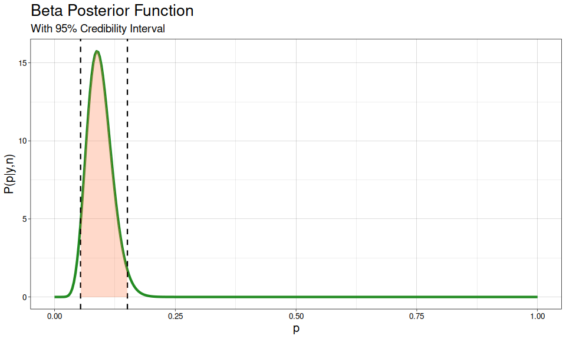

```r
x_area <- seq(l_bound_CI, u_bound_CI, length.out = x_data)
y_ribbon <- dbeta(x_area, alpha_posterior,  beta_posterior)



plot <- ggplot() + theme_linedraw() +
  geom_line(aes(x=x_ax, y=posterior(x_ax)), color='forestgreen', lwd=1.5) +
       geom_vline(xintercept = l_bound_CI , linetype='dashed', lwd=0.8) +
        geom_vline(xintercept = u_bound_CI , linetype='dashed', lwd=0.8) +
        geom_ribbon(aes(x=x_area, ymin=0 , ymax=y_ribbon), alpha =0.3, fill ='coral') +
            ggtitle("Beta Posterior Function") +
            labs(x="p", y='P(p|y,n)', subtitle="With 95% Credibility Interval") +
                        theme(legend.text=element_text(size=12))+
                          theme(plot.title = element_text(size=20),
                          plot.subtitle = element_text(size=14),
                          axis.text.x = element_text(size=10),
                          axis.text.y = element_text(size=10),
                          axis.title.x = element_text(size=15),
                          axis.title.y = element_text(size=15))

plot
```

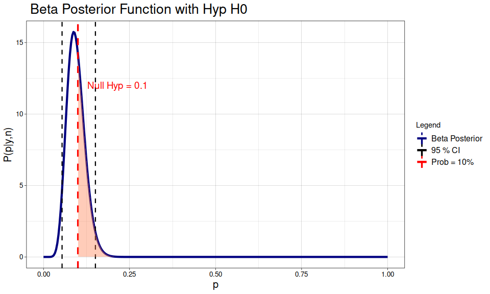

```r
#Test the hyp H0 : p < 0.1

plot <- ggplot() + theme_linedraw() +
  geom_line(aes(x=x_ax, y=posterior(x_ax), color='Beta Posterior'), lwd=1.5) +
   geom_vline(aes(xintercept = l_bound_CI , color='95 % CI'), linetype='dashed', lwd=0.8) +
    geom_vline(aes(xintercept = u_bound_CI ,color='95 % CI'), linetype='dashed',  lwd=0.8) +
  geom_vline( aes(xintercept = 0.1, color = 'Prob = 10%') , linetype='dashed', lwd=1.2)+
  annotate('text', x=0.1+0.115, y=12, label=paste('Null Hyp = 0.1'), color='red', size=5)+
geom_ribbon(aes(x=seq(0.1,1,0.01),ymin=0,ymax=dbeta(seq(0.1,1,0.01),alpha_posterior,beta_posterior)),alpha=0.4,fill ='coral')   + ggtitle(" Beta Posterior Function with Hyp H0")+
            labs(x="p", y='P(p|y,n)', color='Legend') +
                        theme(legend.text=element_text(size=12))+
                          theme(plot.title = element_text(size=20),
                          axis.text.x = element_text(size=10),
                          axis.text.y = element_text(size=10),
                          axis.title.x = element_text(size=15),
                          axis.title.y = element_text(size=15)) +
     scale_color_manual(values = c( 'Beta Posterior' = 'navy', '95 % CI' = 'black', 'Prob = 10%'='red'))

plot
```

```r
prob <- integrate(posterior, lower=0.10,upper = 1)

cat("The Probability of the Null Hypothesis lies in the 95% CI ( (1 - alpha) * 100%)). \n So, with the Bayesian approach, we can not reject the Null Hyp")
```

```
The Probability of the Null Hypothesis lies in the 95% CI ( (1 - alpha) * 100%)).
 So, with the Bayesian approach, we can not reject the Null Hyp
```

```r
cat("In fact the zone of interest corresponds to a Probability of", round(prob$value ,4))
```

```
In fact the zone of interest corresponds to a Probability of 0.3858
```

```r
if(prob$value < 0.05){
  cat("The value of the integral is smaller than the alpha level of significance (5%), so we reject the null hypothesis")
} else{
  cat("The value of the integral is greater than the alpha level of significance (5%), so we can not reject the null hypothesis")
}
```

```
The value of the integral is greater than the alpha level of significance (5%), so we can not reject the null hypothesis
```

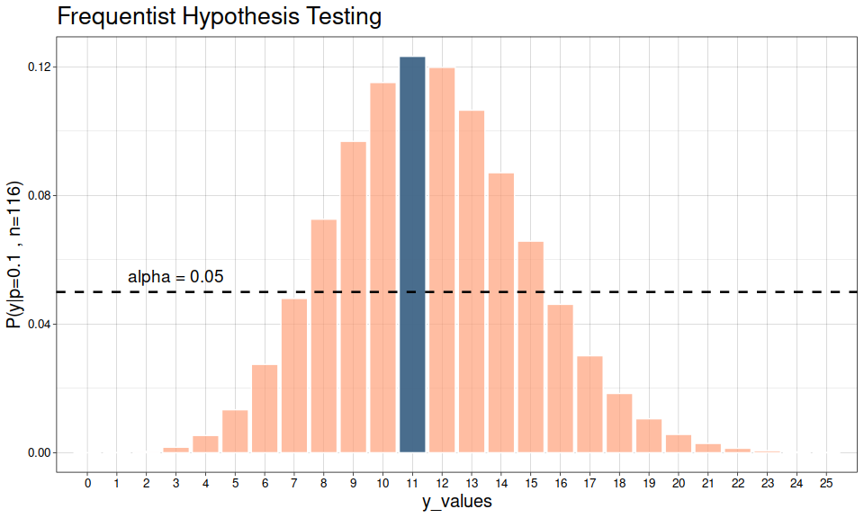

```r
p_null <- 0.1
y_vec <- 0:25

plot <- ggplot() + theme_linedraw() +
  geom_col(aes(x=y_vec, y=dbinom(y_vec, size = n_sample, prob=p_null)), color='white', fill='lightsalmon', alpha=0.7) +
  geom_col(aes(x=11, y=dbinom(11, size = n_sample, prob=p_null)), color='white', fill='steelblue4', alpha=0.9) +
  geom_hline(yintercept=0.05, color='black', linetype='dashed', size=0.9)+
  annotate('text', x=3, y=0.055, label='alpha = 0.05', size=5)+
     ggtitle("Frequentist Hypothesis Testing") +
            labs(x="y_values", y='P(y|p=0.1 , n=116)') +
                          theme(plot.title = element_text(size=20),
                          axis.text.x = element_text(size=10),
                          axis.text.y = element_text(size=10),
                          axis.title.x = element_text(size=15),
                          axis.title.y = element_text(size=15))+
                      scale_x_discrete(limits=(0:25), labels=0:25)

plot
```

```r
cat('We see that y=11 is in the acceptance region, then we do not reject the null hypothesis, \nin fact the value at y = 11 is:', round(dbinom(11, size = n_sample, prob = p_null),3), '> 0.05')
```

```
We see that y=11 is in the acceptance region, then we do not reject the null hypothesis,
in fact the value at y = 11 is: 0.123 > 0.05
```

$y=11$ lies in the acceptance region, so we can not reject the null hypothesis $H_0$ also with the frequentist approach

Evaluating the p-value for the Fisher’s Method :
$$p\text{-}value = \sum_{y=0}^{11}{P(y|p_0,n)} = \sum_{y=0}^{11}{Binom(y|p_0,n)}$$

```r
p_val <- pbinom(11,n_sample,p_null)+1-pbinom(n_sample-11-1, n_sample, p_null)

cat("The calculated p-value is -->", round(p_val,4))
```

```
The calculated p-value is --> 0.5043
```

```r
if(p_val < 0.05){
  cat("The p-value is smaller than the alpha level of significance (5%), so we reject the null hypothesis")
} else{
  cat("The p-value is greater than the alpha level of significance (5%), so we can not reject the null hypothesis")
}
```

```
The p-value is greater than the alpha level of significance (5%), so we can not reject the null hypothesis
```

```r
#e)
n_sample <- 165
y_hb <- 9

f_estim <- y_hb/n_sample
cat("After the new measurement the frequentist estimator for p, having an high bacter level is:", round(f_estim,3))
```

```
After the new measurement the frequentist estimator for p, having an high bacter level is: 0.055
```

```r
#f)
x_data <- 300
x_ax <- seq(0,1,length.out = x_data)

#beta prior Beta(1,10)
alpha_prior_1 <- 1
beta_prior_1 <- 10

#beta prior is a conjugate of a binomial likelihood -> beta posterior

alpha_posterior_1 <- alpha_prior_1 + y_hb
beta_posterior_1 <- beta_prior_1 + n_sample - y_hb

mu_post_1 <- (alpha_posterior_1)/(alpha_posterior_1 + beta_posterior_1)
var_post_1 <- (alpha_posterior_1*beta_posterior_1)/( ((alpha_posterior_1 + beta_posterior_1)^2)*(alpha_posterior_1 + beta_posterior_1 + 1))

posterior_1 <- function(x){ dbeta(x,alpha_posterior_1,beta_posterior_1) }


l_bound_CI_1 <- qgamma(0.025, alpha_posterior_1, beta_posterior_1)
u_bound_CI_1 <- qbeta(0.975,  alpha_posterior_1, beta_posterior_1)


#--------------------------------#
#OLD Posterior as prior: Beta(12,115)
alpha_prior_2 <- 12
beta_prior_2 <- 115

#beta prior is a conjugate of a binomial likelihood -> beta posterior

alpha_posterior_2 <- alpha_prior_2 + y_hb
beta_posterior_2 <- beta_prior_2 + n_sample - y_hb

mu_post_2 <- (alpha_posterior_2)/(alpha_posterior_2 + beta_posterior_2)
var_post_2 <- (alpha_posterior_2*beta_posterior_2)/( ((alpha_posterior_2 + beta_posterior_2)^2)*(alpha_posterior_2 + beta_posterior_2 + 1))


posterior_2 <- function(x){ dbeta(x,alpha_posterior_2,beta_posterior_2) }


l_bound_CI_2 <- qgamma(0.025, alpha_posterior_2, beta_posterior_2)
u_bound_CI_2 <- qbeta(0.975,  alpha_posterior_2, beta_posterior_2)


df <- data.frame(row.names=c("Prior : Beta(1,10)","Prior : Beta(12,115)"))

df["alpha"] <- c(alpha_posterior_1 , alpha_posterior_2)
df["beta"] <- c(beta_posterior_1 , beta_posterior_2)
df["Mean - Bayesian Estim."] <- c(mu_post_1, mu_post_2)
df["Variance"] <- c(var_post_1, var_post_2)
df["Lower_Bound_CI"] <- c(l_bound_CI_1, l_bound_CI_2)
df["Upper_Bound_CI"] <- c(u_bound_CI_1, u_bound_CI_2)


is.num <- sapply(df, is.numeric)
df[is.num] <- lapply(df[is.num], round, 4)

df
```

|  | alpha | beta | Mean - Bayesian Estim. | Variance | Lower_Bound_CI | Upper_Bound_CI |
| --- | --- | --- | --- | --- | --- | --- |
| Prior : Beta(1,10) | 10 | 166 | 0.0568 | 3e-04 | 0.0289 | 0.0954 |
| Prior : Beta(12,115) | 21 | 271 | 0.0719 | 2e-04 | 0.0480 | 0.1042 |

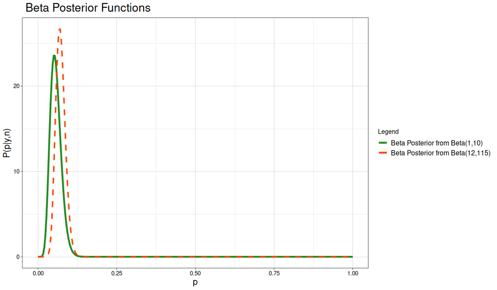

```r
plot <- ggplot() + theme_linedraw() +
  geom_line(aes(x=x_ax, y=posterior_1(x_ax), color='Beta Posterior from Beta(1,10)'), lwd=1.5) +
  geom_line(aes(x=x_ax, y=posterior_2(x_ax), color='Beta Posterior from Beta(12,115)'), lwd=1.2, linetype= 'dashed') +
            ggtitle(" Beta Posterior Functions")+
            labs(x="p", y='P(p|y,n)', color='Legend') +
                        theme(legend.text=element_text(size=12))+
                          theme(plot.title = element_text(size=20),
                          axis.text.x = element_text(size=10),
                          axis.text.y = element_text(size=10),
                          axis.title.x = element_text(size=15),
                          axis.title.y = element_text(size=15)) +
     scale_color_manual(values = c( 'Beta Posterior from Beta(1,10)' = 'forestgreen',
                                    'Beta Posterior from Beta(12,115)'='orangered'))

plot
```

```r
NA
NA
```

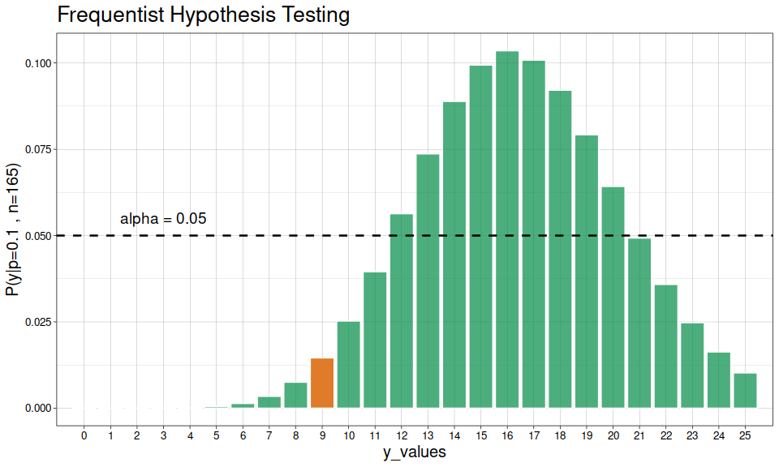

```r
p_null <- 0.1
y_vec <- 0:25

plot <- ggplot() + theme_linedraw() +
  geom_col(aes(x=y_vec, y=dbinom(y_vec, size = n_sample, prob=p_null)), color='white', fill='springgreen4', alpha=0.7) +
  geom_col(aes(x=9, y=dbinom(9, size = n_sample, prob=p_null)), color='white', fill='chocolate2', alpha=0.9) +
  geom_hline(yintercept=0.05, color='black', linetype='dashed', size=0.9)+
  annotate('text', x=3, y=0.055, label='alpha = 0.05', size=5)+
     ggtitle("Frequentist Hypothesis Testing") +
            labs(x="y_values", y='P(y|p=0.1 , n=165)') +
                          theme(plot.title = element_text(size=20),
                          axis.text.x = element_text(size=10),
                          axis.text.y = element_text(size=10),
                          axis.title.x = element_text(size=15),
                        axis.title.y = element_text(size=15)) +
                      scale_x_discrete(limits=(0:25), labels=0:25)

plot
```

```r
cat('We see that y=9 is in the rejection region, then we can not accept the null hypothesis, \nin fact the value at y = 9 is:', round(dbinom(9, size = n_sample, prob = p_null),3), '< 0.05')
```

```
We see that y=9 is in the rejection region, then we can not accept the null hypothesis,
in fact the value at y = 9 is: 0.015 < 0.05
```

$y=9$ lies in the rejection region, so we can not accept the null hypothesis $H_0$ with the frequentist approach

Evaluating the p-value for the Fisher’s Method :
$$p\text{-}value = \sum_{y=0}^{9}{P(y|p_0,n)} = \sum_{y=0}^{9}{Binom(y|p_0,n)}$$

```r
p_val <- pbinom(9,n_sample,p_null)+1-pbinom(n_sample-9-1, n_sample, p_null)

cat("The calculated p-value is -->", round(p_val,4))
```

```
The calculated p-value is --> 0.0275
```

```r
if(p_val < 0.05){
  cat("The p-value is smaller than the alpha level of significance (5%), so we reject the null hypothesis")
} else{
  cat("The p-value is greater than the alpha level of significance (5%), so we can not reject the null hypothesis")
}
```

```
The p-value is smaller than the alpha level of significance (5%), so we reject the null hypothesis
```

With the Bayesian approach, I evaluate if the $p_0=0.1$ lies in the Credibility Interval, obtained as $(1 - \alpha) \cdot 100\% = 95 \%$ for both of the Posterior Functions obtained from the two different Priors.

If $p_0$ lies inside the CI –> I can not reject the Null Hypothesis $H_0$, otherwise, if it lies outside –> I can reject $H_0$

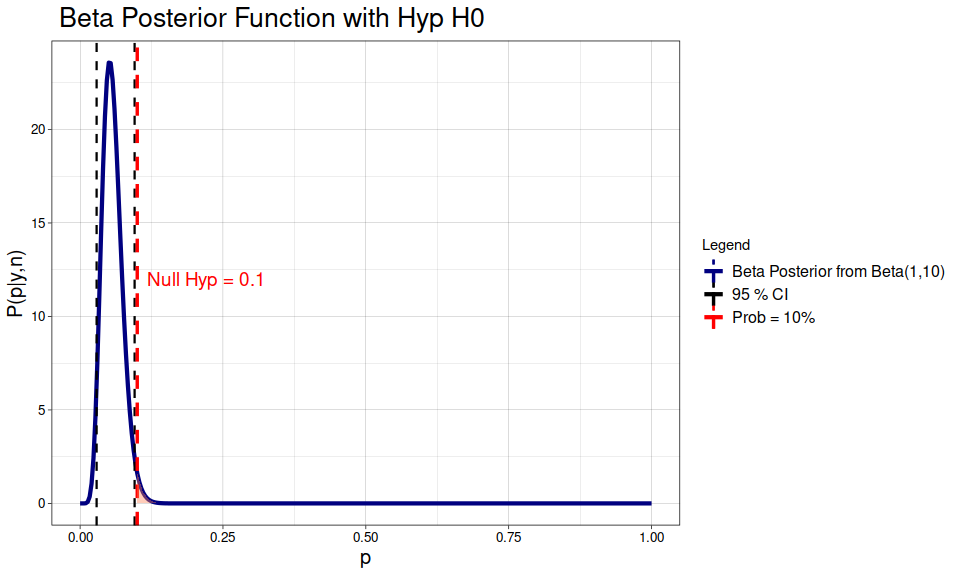

```r
#Test the hyp H0 : p < 0.1 with Bayesian Approach

#Beta(1,10) prior

plot <- ggplot() + theme_linedraw() +
  geom_line(aes(x=x_ax, y=posterior_1(x_ax), color='Beta Posterior from Beta(1,10)'), lwd=1.5) +
   geom_vline(aes(xintercept = l_bound_CI_1 , color='95 % CI'), linetype='dashed', lwd=0.8) +
    geom_vline(aes(xintercept = u_bound_CI_1 ,color='95 % CI'), linetype='dashed',  lwd=0.8) +
  geom_vline( aes(xintercept = 0.1, color = 'Prob = 10%') , linetype='dashed', lwd=1.2)+
  annotate('text', x=0.1+0.122, y=12, label=paste('Null Hyp = 0.1'), color='red', size=5)+
geom_ribbon(aes(x=seq(0.1,1,0.01),ymin=0,ymax=dbeta(seq(0.1,1,0.01),alpha_posterior_1,beta_posterior_1)),alpha=0.4,fill ='coral')   + ggtitle(" Beta Posterior Function with Hyp H0")+
            labs(x="p", y='P(p|y,n)', color='Legend') +
                        theme(legend.text=element_text(size=12))+
                          theme(plot.title = element_text(size=20),
                          axis.text.x = element_text(size=10),
                          axis.text.y = element_text(size=10),
                          axis.title.x = element_text(size=15),
                          axis.title.y = element_text(size=15)) +
     scale_color_manual(values = c( 'Beta Posterior from Beta(1,10)' = 'navy', '95 % CI' = 'black', 'Prob = 10%'='red'))

plot
```

```r
cat("The Probability of the Null Hypothesis lies outside the 95% CI ( (1 - alpha) * 100%)). \n So, with the Bayesian approach, we can reject the Null Hyp")
```

```
The Probability of the Null Hypothesis lies outside the 95% CI ( (1 - alpha) * 100%)).
 So, with the Bayesian approach, we can reject the Null Hyp
```

```r
cat("95 % Credibility Interval :
    \t", l_bound_CI_1, "-", u_bound_CI_1,"
    \t \t p0 = 0.1 is outside")
```

```
95 % Credibility Interval :
         0.02888788 - 0.09538012
             p0 = 0.1 is outside
```

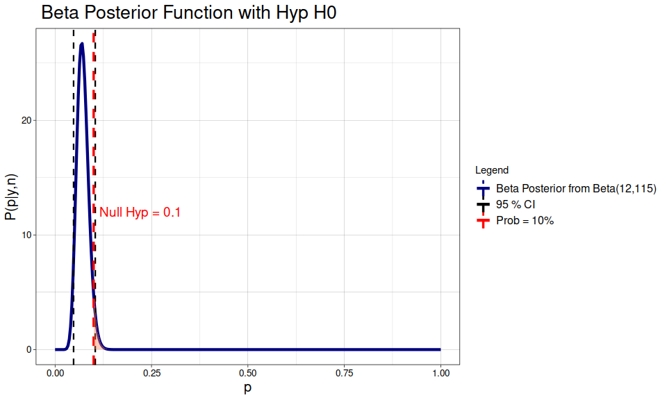

```r
#Test the hyp H0 : p < 0.1 with Bayesian Approach

#Beta(12,115) prior

plot <- ggplot() + theme_linedraw() +
  geom_line(aes(x=x_ax, y=posterior_2(x_ax), color='Beta Posterior from Beta(12,115)'), lwd=1.5) +
   geom_vline(aes(xintercept = l_bound_CI_2 , color='95 % CI'), linetype='dashed', lwd=0.8) +
    geom_vline(aes(xintercept = u_bound_CI_2 ,color='95 % CI'), linetype='dashed',  lwd=0.8) +
  geom_vline( aes(xintercept = 0.1, color = 'Prob = 10%') , linetype='dashed', lwd=1.2)+
  annotate('text', x=0.1+0.122, y=12, label=paste('Null Hyp = 0.1'), color='red', size=5)+
geom_ribbon(aes(x=seq(0.1,1,0.01),ymin=0,ymax=dbeta(seq(0.1,1,0.01),alpha_posterior_2,beta_posterior_2)),alpha=0.4,fill ='coral')   + ggtitle(" Beta Posterior Function with Hyp H0")+
            labs(x="p", y='P(p|y,n)', color='Legend') +
                        theme(legend.text=element_text(size=12))+
                          theme(plot.title = element_text(size=20),
                          axis.text.x = element_text(size=10),
                          axis.text.y = element_text(size=10),
                          axis.title.x = element_text(size=15),
                          axis.title.y = element_text(size=15)) +
     scale_color_manual(values = c( 'Beta Posterior from Beta(12,115)' = 'navy', '95 % CI' = 'black', 'Prob = 10%'='red'))

plot
```

```r
cat("The Probability of the Null Hypothesis lies inside the 95% CI ( (1 - alpha) * 100%)). \n So, with the Bayesian approach, we can not reject the Null Hyp")
```

```
The Probability of the Null Hypothesis lies inside the 95% CI ( (1 - alpha) * 100%)).
 So, with the Bayesian approach, we can not reject the Null Hyp
```

```r
cat("95 % Credibility Interval :
    \t", l_bound_CI_2, "-", u_bound_CI_2,"
    \t \t p0 = 0.1 is inside")
```

```
95 % Credibility Interval :
         0.04796801 - 0.1041519
             p0 = 0.1 is inside
```

The results are different between the two cases:

• with Beta(1,10) as a prior, we reject the null hyp $H_0$

• with the old posterior Beta(12,115) as a prior, we accept $H_0$

## Exercise 4

• analyze the data of Exercise 1 using a MCMC with JAGS (solve only point a of Ex 1)

```r
mu_beta <- 0.15
sigma_beta <- 0.14

y_fail <- 6
n_sample <- 75

alpha_prior <- (-mu_beta*(sigma_beta^2 + mu_beta^2 - mu_beta))/(sigma_beta^2)
beta_prior <- ((sigma_beta^2 + mu_beta^2 - mu_beta)*(mu_beta -1))/(sigma_beta^2)

alpha_posterior <- alpha_prior + y_fail
beta_posterior <- beta_prior + n_sample - y_fail

posterior <- function(x){
  dbeta(x, alpha_posterior, beta_posterior)
}


data_obs <- rep(c(1,0), c(y_fail, n_sample-y_fail) )

data <- NULL
data$a_prior <- alpha_prior
data$b_prior <- beta_prior
data$X <- data_obs
data$n <- length(data_obs)


model <- 'bugs/ex_1.bug'
jm <- jags.model(model, data=data)
```

```
Unused variable "n" in data
```

```r
# Update the Markov chain (Burn -in)
update (jm , 1000)
```

[output not shown]

```r
#Run MCMC
chain <- coda.samples(jm , c("p"), n.iter=10000)
```

[output not shown]

```r
s <- summary(chain)
print(s)
```

```
Iterations = 1001:11000
Thinning interval = 1
Number of chains = 1
Sample size per chain = 10000

1. Empirical mean and standard deviation for each variable,
   plus standard error of the mean:

          Mean             SD       Naive SE Time-series SE
     0.0844562      0.0306447      0.0003064      0.0002888

2. Quantiles for each variable:

   2.5%     25%     50%     75%   97.5%
0.03456 0.06222 0.08140 0.10355 0.15306
```

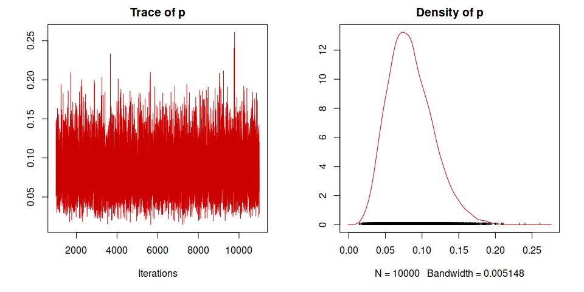

```r
plot(chain, col="red3")
```

```r
chain.df <- as.data.frame( as.mcmc(chain) )
head(chain.df)
```

|  | p |
| --- | --- |
| 1 | 0.05121663 |
| 2 | 0.06944321 |
| 3 | 0.14627036 |
| 4 | 0.10853771 |
| 5 | 0.11465703 |
| 6 | 0.08512872 |

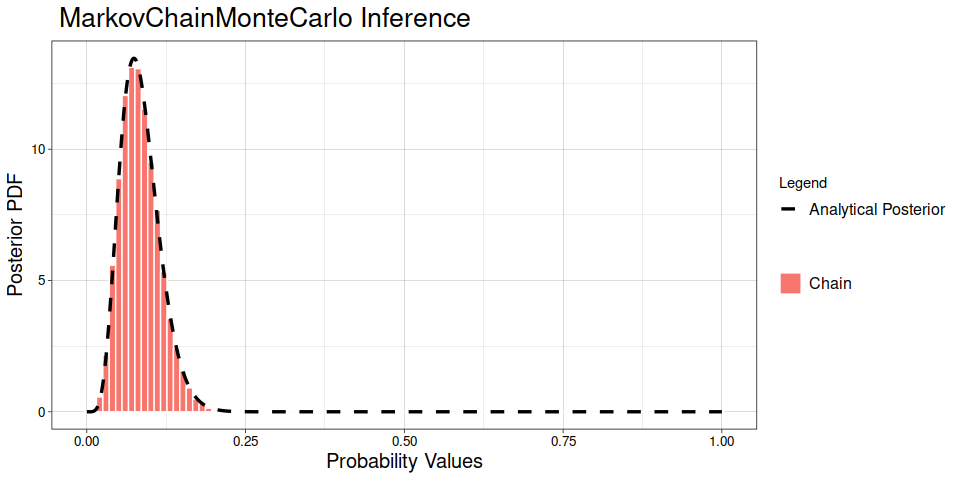

```r
x_ax <- seq(0,1,0.001)

plot <- ggplot() + theme_linedraw() +
  geom_histogram(aes(chain.df$p, y=..density.., fill= 'Chain'), color='white', bins=100) +
  geom_line( aes(x=x_ax, y=posterior(x_ax), color = 'Analytical Posterior') , linetype='dashed', lwd=1.2)+ ggtitle(" MarkovChainMonteCarlo Inference")+
            labs(x="Probability Values", y='Posterior PDF', color='Legend', fill='') +
                        theme(legend.text=element_text(size=12))+
                          theme(plot.title = element_text(size=20),
                          axis.text.x = element_text(size=10),
                          axis.text.y = element_text(size=10),
                          axis.title.x = element_text(size=15),
                          axis.title.y = element_text(size=15)) +
     scale_color_manual(values = c('Analytical Posterior'='black'))

plot
```

```r
stat_values <- s$statistics

df <- data.frame(row.names=c("Chain"))

df["Mean"] <- stat_values[['Mean']]
df["Sigma"] <- stat_values[['SD']]
df["Median"] <- s$quantiles[['50%']]
df["Lower_Bound_CI"] <- s$quantiles[['2.5%']]
df["Upper_Bound_CI"] <- s$quantiles[['97.5%']]

is.num <- sapply(df, is.numeric)
df[is.num] <- lapply(df[is.num], round, 4)

df
```

|  | Mean | Sigma | Median | Lower_Bound_CI | Upper_Bound_CI |
| --- | --- | --- | --- | --- | --- |
| Chain | 0.0845 | 0.0306 | 0.0814 | 0.0346 | 0.1531 |

## Exercise 5

• analyze the data of Exercise 2 using a MCMC with JAGS

```r
deaths <- c(0,1,2,3,4,5)
n1 <- c(109,65,22,3,1,0)
n2 <- c(144,91,32,11,2,0)


n_tot <- n1 + n2
data_obs <- rep(deaths , n_tot)

data <- NULL
data$X <- data_obs


model <- 'bugs/ex_2.bug'
jm <- jags.model(model, data=data)
# Update the Markov chain (Burn -in)
update (jm , 1000)
```

[output not shown]

```r
#Run MCMC
chain <- coda.samples(jm , c("lambda"), n.iter=10000)
```

[output not shown]

```r
s <- summary(chain)
print(s)
```

```
Iterations = 1001:11000
Thinning interval = 1
Number of chains = 1
Sample size per chain = 10000

1. Empirical mean and standard deviation for each variable,
   plus standard error of the mean:

          Mean             SD       Naive SE Time-series SE
     0.6649987      0.0375063      0.0003751      0.0003944

2. Quantiles for each variable:

  2.5%    25%    50%    75%  97.5%
0.5926 0.6399 0.6638 0.6895 0.7412
```

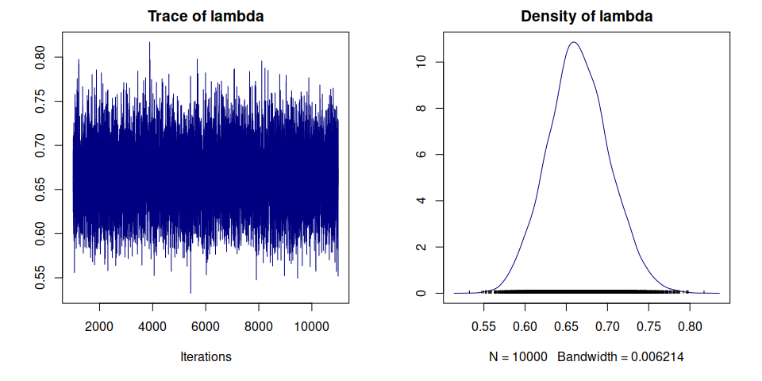

```r
plot(chain, col="navy")
```

```r
chain.df <- as.data.frame( as.mcmc(chain) )
head(chain.df)
```

|  | lambda |
| --- | --- |
| 1 | 0.6594056 |
| 2 | 0.6473409 |
| 3 | 0.6943511 |
| 4 | 0.6462240 |
| 5 | 0.6635354 |
| 6 | 0.6243448 |

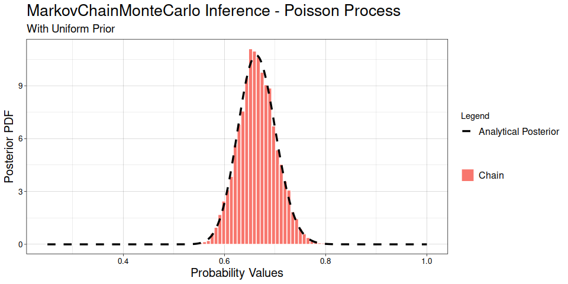

```r
alpha_post <- sum(deaths*(n1 + n2)) + 1
beta_post <- sum(n1 + n2)

posterior <- function(x){
  dgamma(x , shape = alpha_post, rate = beta_post)
}

x_ax <- seq(0.25,1, 0.001)

plot <- ggplot() + theme_linedraw() +
  geom_histogram(aes(chain.df$lambda, y=..density.., fill= 'Chain'), color='white', bins=100) +
  geom_line( aes(x=x_ax, y=posterior(x_ax), color = 'Analytical Posterior') , linetype='dashed', lwd=1.2)+ ggtitle("MarkovChainMonteCarlo Inference - Poisson Process")+
            labs(x="Probability Values", y='Posterior PDF', color='Legend',
                 subtitle="With Uniform Prior", fill='') +
                        theme(legend.text=element_text(size=12))+
                          theme(plot.title = element_text(size=20),
                          plot.subtitle = element_text(size=14),
                          axis.text.x = element_text(size=10),
                          axis.text.y = element_text(size=10),
                          axis.title.x = element_text(size=15),
                          axis.title.y = element_text(size=15)) +
     scale_color_manual(values = c('Analytical Posterior'='black'))

plot
```

```r
model <- 'bugs/ex_2_jef.bug'
jm <- jags.model(model, data=data)
```

[output not shown]

```r
# Update the Markov chain (Burn -in)
update (jm , 1000)
```

[output not shown]

```r
#Run MCMC
chain_j <- coda.samples(jm , c("lambda"), n.iter=10000)
```

[output not shown]

```r
s_j <- summary(chain_j)
print(s_j)
```

```
Iterations = 2001:12000
Thinning interval = 1
Number of chains = 1
Sample size per chain = 10000

1. Empirical mean and standard deviation for each variable,
   plus standard error of the mean:

          Mean             SD       Naive SE Time-series SE
     0.6667887      0.0374744      0.0003747      0.0004823

2. Quantiles for each variable:

  2.5%    25%    50%    75%  97.5%
0.5952 0.6414 0.6660 0.6918 0.7422
```

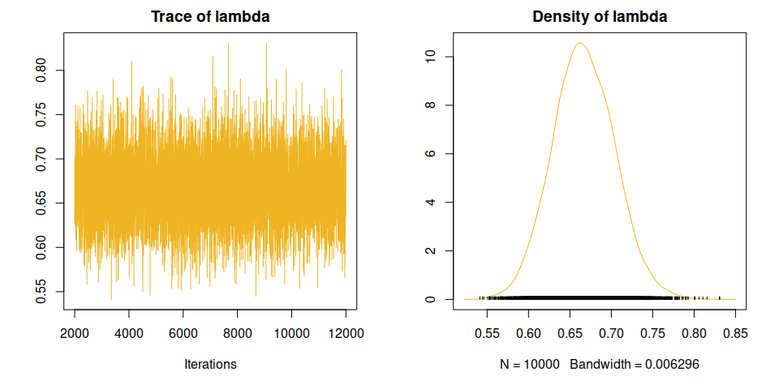

```r
plot(chain_j, col="goldenrod2")
```

```r
chain_j.df <- as.data.frame( as.mcmc(chain_j) )
head(chain_j.df)
```

|  | lambda |
| --- | --- |
| 1 | 0.6297294 |
| 2 | 0.6546523 |
| 3 | 0.6858099 |
| 4 | 0.7018322 |
| 5 | 0.6709398 |
| 6 | 0.6766184 |

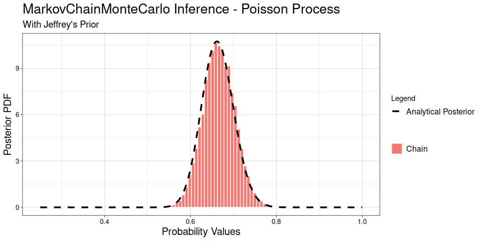

```r
alpha_post <- sum(deaths*(n1 + n2)) + 1/2
beta_post <- sum(n1 + n2)

posterior_j <- function(x){
  dgamma(x , shape = alpha_post, rate = beta_post)
}

x_ax <- seq(0.25,1, 0.001)

plot <- ggplot() + theme_linedraw() +
  geom_histogram(aes(chain_j.df$lambda, y=..density.., fill= 'Chain'), color='white', bins=100) +
  geom_line( aes(x=x_ax, y=posterior_j(x_ax), color = 'Analytical Posterior') , linetype='dashed', lwd=1.2)+ ggtitle("MarkovChainMonteCarlo Inference - Poisson Process")+
            labs(x="Probability Values", y='Posterior PDF', color='Legend',
                 subtitle="With Jeffrey's Prior" , fill='') +
                        theme(legend.text=element_text(size=12))+
                          theme(plot.title = element_text(size=20),
                          plot.subtitle = element_text(size=14),
                          axis.text.x = element_text(size=10),
                          axis.text.y = element_text(size=10),
                          axis.title.x = element_text(size=15),
                          axis.title.y = element_text(size=15)) +
     scale_color_manual(values = c('Analytical Posterior'='black'))

plot
```

```r
stat_values <- s$statistics
stat_values_j <- s_j$statistics

df <- data.frame(row.names=c("Chain - Uniform Prior","Chain - Jeffrey's Prior" ))

df["Mean"] <- c(stat_values[['Mean']], stat_values_j[['Mean']])
df["Sigma"] <- c(stat_values[['SD']], stat_values[['SD']])
df["Median"] <- c(s$quantiles[['50%']], s_j$quantiles[['50%']])
df["Lower_Bound_CI"] <- c(s$quantiles[['2.5%']],s_j$quantiles[['2.5%']])
df["Upper_Bound_CI"] <- c(s$quantiles[['97.5%']],s_j$quantiles[['97.5%']])

is.num <- sapply(df, is.numeric)
df[is.num] <- lapply(df[is.num], round, 4)

df
```

|  | Mean | Sigma | Median | Lower_Bound_CI | Upper_Bound_CI |
| --- | --- | --- | --- | --- | --- |
| Chain - Uniform Prior | 0.6650 | 0.0375 | 0.6638 | 0.5926 | 0.7412 |
| Chain - Jeffrey's Prior | 0.6668 | 0.0375 | 0.6660 | 0.5952 | 0.7422 |

## Exercise 6

• analyze the data of Exercise 3 using a MCMC with JAGS (solve point b and c)

```r
n_sample <- 116
y_hb <- 11

data_obs <- rep(c(1,0), c(y_hb, n_sample-y_hb) )

data <- NULL
data$X <- data_obs
data$n <- length(data_obs)


model <- 'bugs/ex_3.bug'
jm <- jags.model(model, data=data)
```

```
Unused variable "n" in data
```

```r
# Update the Markov chain (Burn -in)
update (jm , 1000)
```

[output not shown]

```r
#Run MCMC
chain <- coda.samples(jm , c("p"), n.iter=10000)
```

[output not shown]

```r
s <- summary(chain)
print(s)
```

```
Iterations = 1001:11000
Thinning interval = 1
Number of chains = 1
Sample size per chain = 10000

1. Empirical mean and standard deviation for each variable,
   plus standard error of the mean:

          Mean             SD       Naive SE Time-series SE
     0.0941957      0.0257837      0.0002578      0.0002499

2. Quantiles for each variable:

   2.5%     25%     50%     75%   97.5%
0.05063 0.07578 0.09186 0.11049 0.15061
```

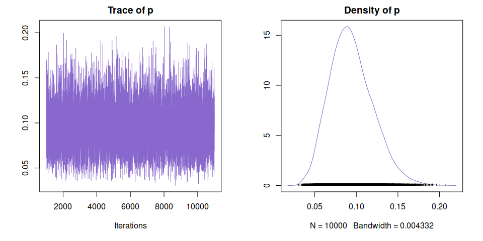

```r
plot(chain, col="mediumpurple3")
```

```r
chain.df <- as.data.frame( as.mcmc(chain) )
head(chain.df)
```

|  | p |
| --- | --- |
| 1 | 0.07409109 |
| 2 | 0.09112963 |
| 3 | 0.12137644 |
| 4 | 0.10799142 |
| 5 | 0.09178376 |
| 6 | 0.08162835 |

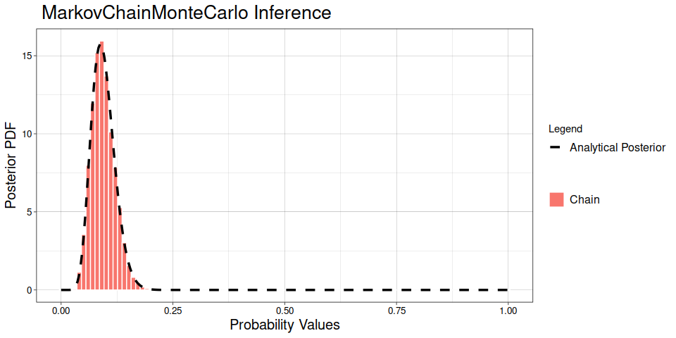

```r
#beta prior Beta(1,10)
alpha_prior <- 1
beta_prior <- 10

alpha_posterior <- alpha_prior + y_hb
beta_posterior <- beta_prior + n_sample - y_hb


posterior <- function(x){
  dbeta(x, alpha_posterior, beta_posterior)
}

x_data <- 300
x_ax <- seq(0,1,length.out = x_data)

plot <- ggplot() + theme_linedraw() +
  geom_histogram(aes(chain.df$p, y=..density.., fill= 'Chain'), color='white', bins=100) +
  geom_line( aes(x=x_ax, y=posterior(x_ax), color = 'Analytical Posterior') , linetype='dashed', lwd=1.2)+ ggtitle(" MarkovChainMonteCarlo Inference")+
            labs(x="Probability Values", y='Posterior PDF', color='Legend', fill='') +
                        theme(legend.text=element_text(size=12))+
                          theme(plot.title = element_text(size=20),
                          axis.text.x = element_text(size=10),
                          axis.text.y = element_text(size=10),
                          axis.title.x = element_text(size=15),
                          axis.title.y = element_text(size=15)) +
     scale_color_manual(values = c('Analytical Posterior'='black'))

plot
```

```r
stat_values <- s$statistics

df <- data.frame(row.names=c("Chain"))

df["Mean"] <- stat_values[['Mean']]
df["Sigma"] <- stat_values[['SD']]
df["Median"] <- s$quantiles[['50%']]
df["Lower_Bound_CI"] <- s$quantiles[['2.5%']]
df["Upper_Bound_CI"] <- s$quantiles[['97.5%']]

is.num <- sapply(df, is.numeric)
df[is.num] <- lapply(df[is.num], round, 4)

df
```

|  | Mean | Sigma | Median | Lower_Bound_CI | Upper_Bound_CI |
| --- | --- | --- | --- | --- | --- |
| Chain | 0.0942 | 0.0258 | 0.0919 | 0.0506 | 0.1506 |